## Algoritmo de Aprendizaje: Máquinas de Soporte Vectorial (SVM)

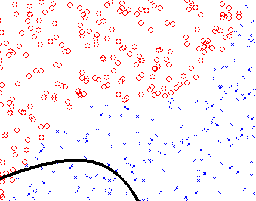

Sabemos que las máquinas de soporte vectorial son una herramienta muy útil para aprendizaje con predictores lineales en dimensiones grandes.

En este caso, se tiene un conjunto de entrenamiento que se prentende separar. Decimos que un conjunto es linealmente separable si existe un subespacio (,b) tal que $y_i=sign(\textbf{w},x_i+b) \forall$ i, pero pueden existir muchos espacios separadores ¿cuál elegir?

En primer lugar, definimos el margen de un hiperplano, con respecto al conjunto de entrenamiento, se define como la mínima distancia entre un punto en el conjunto y el hiperplano. Si un hiperplano tiene un margen amplio, entonces separará los datos aun cuando se perturben.

“Hard-SVM” es la regla de aprendizaje que separa un hiperplano con el margen más amplio posible, por lo que puede verse como un problema de optimización cuadrática, en la que el hiperplano de margen máximo es la solución. Sin embargo, asumir que el conjunto es separable por una línea es un supuesto muy fuerte. Pero cuando existe el hiperplano esto nos proporciona un posible separador.

“Soft-SVM” a diferencia del hard, que asume el conjunto de entrenamiento es linealmente separable, esta variación asume que el conjunto de entrenamiento no es linealmente separable y permite que algunas observaciones “crucen” la restricción, esto es se le añaden variables de holgura no negativas a las restricciones de modo que queden: $y_i((\textbf{w}, x_i)+b) \geqslant 1 - \xi_i$ de manera que la nueva variable de holgura medirá que tanto se esta violando la restricción, lo que también nos indica que con esta variable nosotros podemos decidir que tan fuerte será la violación del margen.

Recordemos el ejemplo de clase con los factores. En este ejemplo teniamos una muestra de entrenamiento, la cual no era linealmente separable, por lo que tenemos un caso de soft-svm.

Paquetería Necesaria

```r
library(caret)
```

```r
library(e1071)
library(ggplot2)
```

Simulación

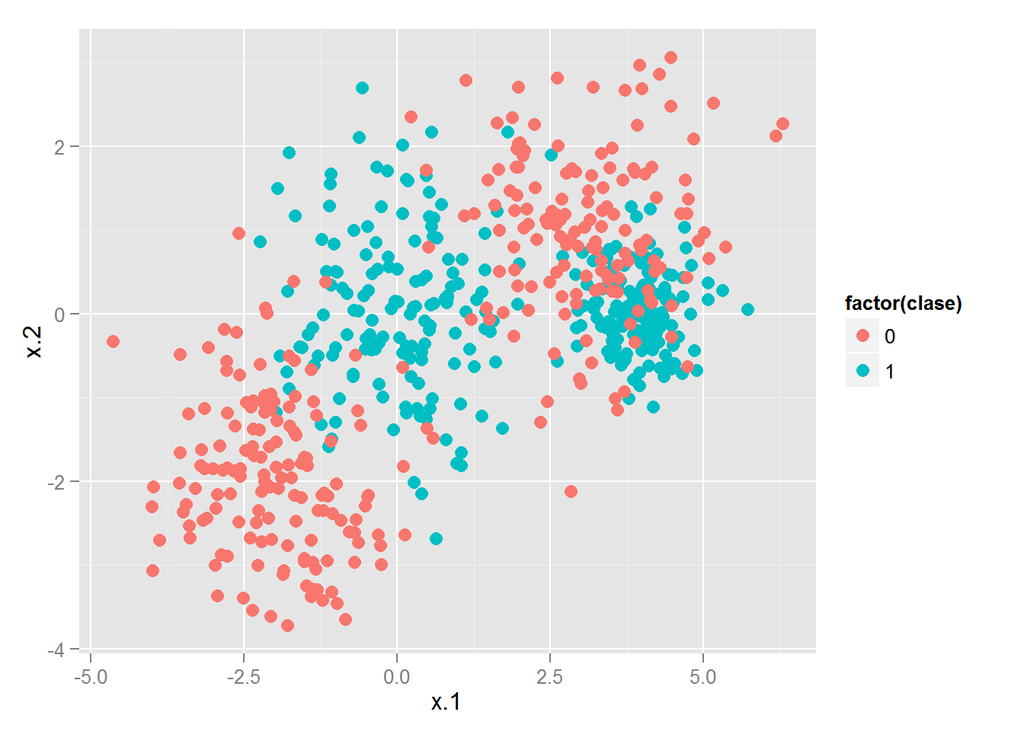

```r
set.seed(280511)
dat.grid <- expand.grid(x.1=seq(-4,6,0.1), x.2=seq(-4,4,0.1))

sim.data <- function(n){
    dat.pos.1 <- data.frame(x.1=rnorm(n,0,1), x.2=rnorm(n,0,1))
    dat.pos.1$clase <- 1
    dat.pos.2 <- data.frame(x.1=rnorm(n,4,0.5), x.2=rnorm(n,0,0.5))
    dat.pos.2$clase <- 1
    dat.pos <- rbind(dat.pos.1, dat.pos.2)
    dat.neg.1 <- data.frame(x.1=rnorm(n,-2,1), x.2=rnorm(n,-2,1))
    dat.neg.2 <- data.frame(x.1=rnorm(n,3,1.2), x.2=rnorm(n,1,1))
    dat.neg <- rbind(dat.neg.1, dat.neg.2)
    dat.neg$clase <- 0
    dat.out <- rbind(dat.pos, dat.neg)
    dat.out$clase <- factor(dat.out$clase)
    dat.out
}
dat.entrena <- sim.data(150)
dat.prueba <- sim.data(5000)
ggplot(dat.entrena, aes(x=x.1, y=x.2, colour=factor(clase)))+geom_point(size=3)
```

Dado que los parámetros de holgura son relativas al margen, queremos averiguar que pasa cuando las hacemos más grandes o más chicas. Tenemos que mientras más chica sea la holgura, buscaremos soluciones que violen poco al margen, pero esto nos provoca que el margen sea más chico y los casos que se encuentren cerca al hiperplano separador podrían no estar bien clasificados.

Por otro lado, cuando hacemos la holgura más grande buscamos soluciones con un margen más alto,i.e. permitimos que algunos casos estén muy mal clasificados con tal de que la mayoría sean bien clasificados con margen alto.

Valuación de holgura:

```r
svm.1 <- svm(clase ~x.1 + x.2 , data=dat.entrena, kernel = 'radial', cost=0.01, gamma=1 )
svm.2 <- svm(clase ~x.1 + x.2, data=dat.entrena, kernel = 'radial', cost=100, gamma=1 )
svm.3 <- svm(clase ~x.1 + x.2, data=dat.entrena, kernel = 'radial', cost=100000, gamma=1 )
dat.grid$pred.1 <- predict(svm.1, newdata = dat.grid)
dat.grid$pred.2 <- predict(svm.2, newdata = dat.grid)
dat.grid$pred.3 <- predict(svm.3, newdata = dat.grid)
```

Todas las gráficas tiene fija en 1 La primer gáfica tiene parámetro de Costo = 0.01 La segunda gráfica tiene parámetro de Costo = 100 La segunda gráfica tiene parámetro de Costo = 100,000

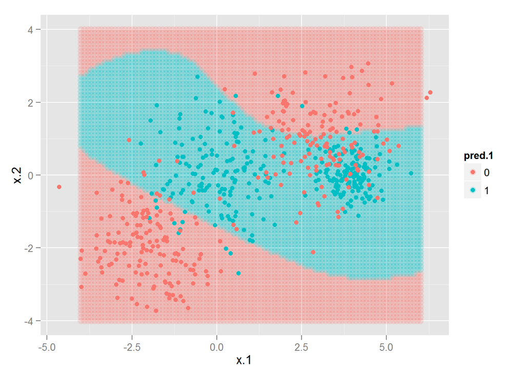

```r
 ggplot(dat.grid, aes(x=x.1, y=x.2))+geom_point(size=3, alpha=0.2, aes(colour=pred.1)) +
    geom_point(data=dat.entrena, aes(colour=factor(clase)))
```

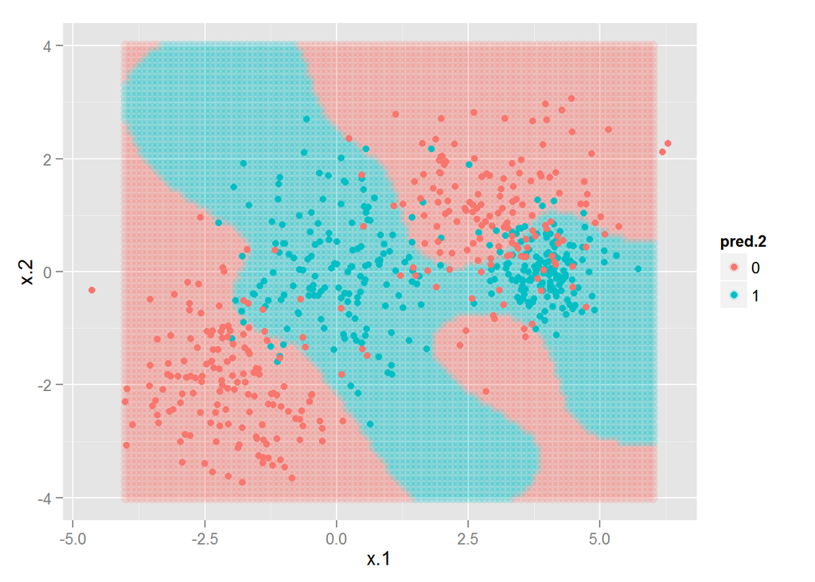

```r
ggplot(dat.grid, aes(x=x.1, y=x.2))+geom_point(size=3, alpha=0.2, aes(colour=pred.2)) +
    geom_point(data=dat.entrena, aes(colour=factor(clase)))
```

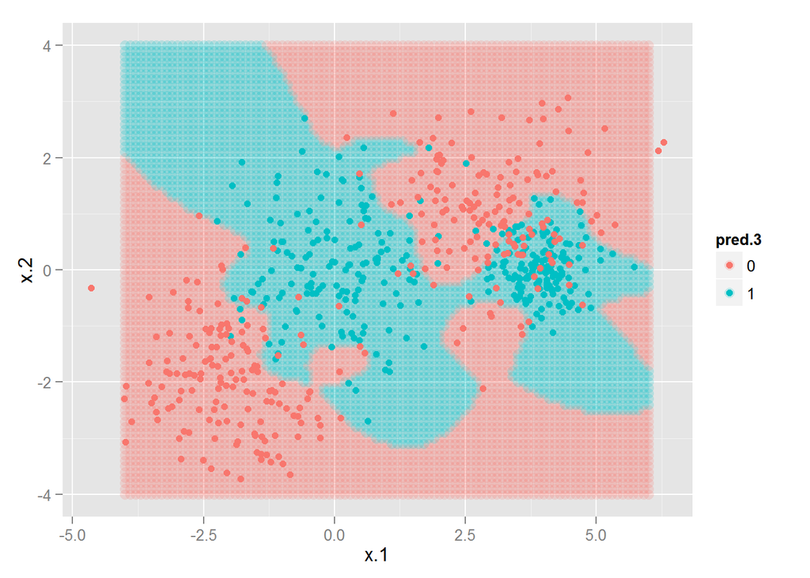

```r
ggplot(dat.grid, aes(x=x.1, y=x.2))+geom_point(size=3, alpha=0.2, aes(colour=pred.3)) +
    geom_point(data=dat.entrena, aes(colour=factor(clase)))
```

Parámetro Gamma $\gamma$ El parámetro gamma establece qué tan rápido caen las similitudes (productos punto entre los datos). Si la gamma crece implica que la similitud decae más rápidamente. Entonces conforma aumenta la gamma aumenta la varianza, pero el sesgo potencialmente decrece.

```r
svm.1 <- svm(clase ~x.1 + x.2 , data=dat.entrena, kernel = 'radial', cost=10, gamma=0.1 )
svm.2 <- svm(clase ~x.1 + x.2, data=dat.entrena, kernel = 'radial', cost=10, gamma=10 )
svm.3 <- svm(clase ~x.1 + x.2, data=dat.entrena, kernel = 'radial', cost=10, gamma=100 )
dat.grid$pred.1 <- predict(svm.1, newdata = dat.grid)
dat.grid$pred.2 <- predict(svm.2, newdata = dat.grid)
dat.grid$pred.3 <- predict(svm.3, newdata = dat.grid)
```

Todas las gráficas tienen el Costo fijo en 10

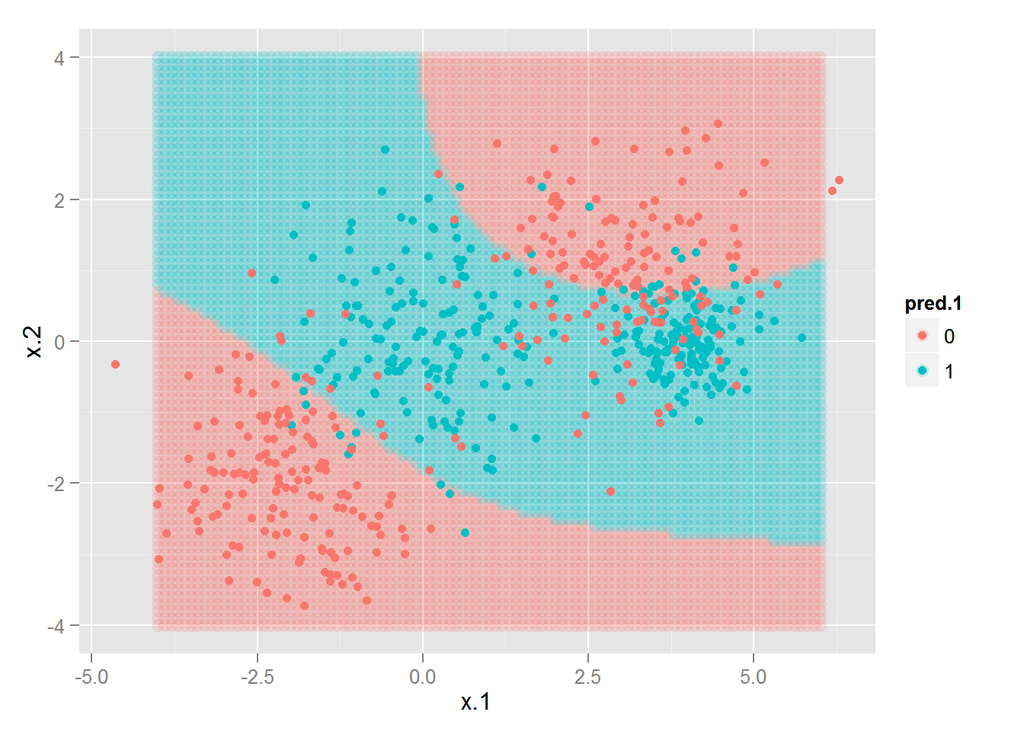

```r
 ggplot(dat.grid, aes(x=x.1, y=x.2))+geom_point(size=3, alpha=0.2, aes(colour=pred.1)) +
    geom_point(data=dat.entrena, aes(colour=factor(clase)))
```

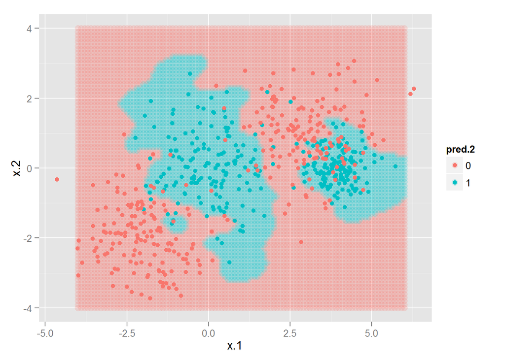

```r
ggplot(dat.grid, aes(x=x.1, y=x.2))+geom_point(size=3, alpha=0.2, aes(colour=pred.2)) +
    geom_point(data=dat.entrena, aes(colour=factor(clase)))
```

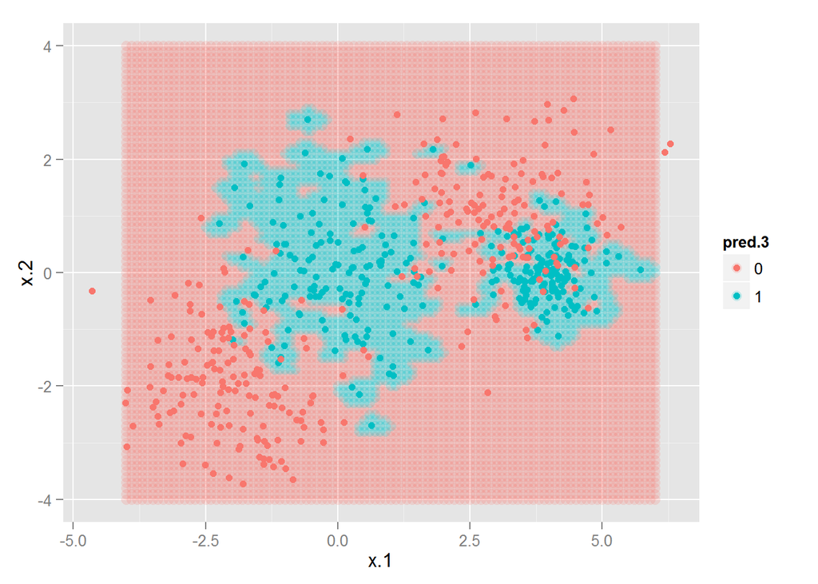

```r
ggplot(dat.grid, aes(x=x.1, y=x.2))+geom_point(size=3, alpha=0.2, aes(colour=pred.3)) +
    geom_point(data=dat.entrena, aes(colour=factor(clase)))
```

¿Qué parámetros seleccionamos? La seleccion de parámetros se da por validación cruzada.

Primero empleando un vector de Costos (0.1,1,10,100) y de $\gamma$ (0.1,1,10,100)

```r
library(doParallel)
registerDoParallel(cores = 6)
set.seed(221)
train.control <- trainControl(method='cv', number=10)
tune.grid <- expand.grid(list(sigma=c(0.1,1,10,100,100),
                              C=c(0.1,1,10,100,100)))
svmFit <- train(x=dat.entrena[,1:2], y=dat.entrena$clase,
    method = "svmRadial", tuneGrid = tune.grid,
    trControl = train.control, scaled = TRUE)
svmFit
```

```
## Support Vector Machines with Radial Basis Function Kernel
##
## 600 samples
##   2 predictor
##   2 classes: '0', '1'
##
## No pre-processing
## Resampling: Cross-Validated (10 fold)
##
## Summary of sample sizes: 540, 540, 540, 540, 540, 540, ...
##
## Resampling results across tuning parameters:
##
##   sigma  C      Accuracy   Kappa      Accuracy SD  Kappa SD
##     0.1    0.1  0.7350000  0.4700000  0.02881401   0.05762801
##     0.1    1.0  0.8083333  0.6166667  0.03535534   0.07071068
##     0.1   10.0  0.8183333  0.6366667  0.03722637   0.07445274
##     0.1  100.0  0.8283333  0.6566667  0.03590924   0.07181848
##     1.0    0.1  0.8283333  0.6566667  0.03047970   0.06095941
##     1.0    1.0  0.8366667  0.6733333  0.03220306   0.06440612
##     1.0   10.0  0.8400000  0.6800000  0.02744242   0.05488484
##     1.0  100.0  0.8416667  0.6833333  0.02676517   0.05353034
##    10.0    0.1  0.8383333  0.6766667  0.03853009   0.07706018
##    10.0    1.0  0.8316667  0.6633333  0.02658552   0.05317105
##    10.0   10.0  0.8283333  0.6566667  0.04010018   0.08020037
##    10.0  100.0  0.8050000  0.6100000  0.04591500   0.09183000
##   100.0    0.1  0.6400000  0.2800000  0.02778363   0.05556725
##   100.0    1.0  0.7983333  0.5966667  0.04288568   0.08577135
##   100.0   10.0  0.7850000  0.5700000  0.04006574   0.08013147
##   100.0  100.0  0.7816667  0.5633333  0.03808074   0.07616147
##
## Accuracy was used to select the optimal model using  the largest value.
## The final values used for the model were sigma = 1 and C = 100.
```

```r
svmFit$finalModel
```

```
## Support Vector Machine object of class "ksvm"
##
## SV type: C-svc  (classification)
##  parameter : cost C = 100
##
## Gaussian Radial Basis kernel function.
##  Hyperparameter : sigma =  1
##
## Number of Support Vectors : 203
##
## Objective Function Value : -18001.11
## Training error : 0.14
```

Obtenemos que los parámetros del modelo óptimo son:

Costo=100  
$\gamma$=1 Con un error de entrenamiento de 0.14

```r
tune.grid <- expand.grid(list(sigma=c(0.25,0.5,1,2,4,8),
                              C=c(0.25,0.5,1,2,4,8,10)))
svmFit.2 <- train(x=dat.entrena[,1:2], y=dat.entrena$clase,
    method = "svmRadial", tuneGrid = tune.grid,
    trControl = train.control, scaled = TRUE)
svmFit.2
```

```
## Support Vector Machines with Radial Basis Function Kernel
##
## 600 samples
##   2 predictor
##   2 classes: '0', '1'
##
## No pre-processing
## Resampling: Cross-Validated (10 fold)
##
## Summary of sample sizes: 540, 540, 540, 540, 540, 540, ...
##
## Resampling results across tuning parameters:
##
##   sigma  C      Accuracy   Kappa      Accuracy SD  Kappa SD
##   0.25    0.25  0.8216667  0.6433333  0.04377975   0.08755950
##   0.25    0.50  0.8183333  0.6366667  0.04335470   0.08670939
##   0.25    1.00  0.8183333  0.6366667  0.04475585   0.08951171
##   0.25    2.00  0.8200000  0.6400000  0.04142523   0.08285045
##   0.25    4.00  0.8233333  0.6466667  0.04245550   0.08491099
##   0.25    8.00  0.8250000  0.6500000  0.04461772   0.08923544
##   0.25   10.00  0.8250000  0.6500000  0.04461772   0.08923544
##   0.50    0.25  0.8200000  0.6400000  0.03912626   0.07825252
##   0.50    0.50  0.8266667  0.6533333  0.04661373   0.09322745
##   0.50    1.00  0.8233333  0.6466667  0.04855950   0.09711899
##   0.50    2.00  0.8216667  0.6433333  0.04972145   0.09944289
##   0.50    4.00  0.8266667  0.6533333  0.05163978   0.10327956
##   0.50    8.00  0.8266667  0.6533333  0.04981447   0.09962894
##   0.50   10.00  0.8300000  0.6600000  0.05079613   0.10159226
##   1.00    0.25  0.8300000  0.6600000  0.04766136   0.09532271
##   1.00    0.50  0.8300000  0.6600000  0.04893937   0.09787874
##   1.00    1.00  0.8316667  0.6633333  0.04611446   0.09222892
##   1.00    2.00  0.8383333  0.6766667  0.04447915   0.08895831
##   1.00    4.00  0.8383333  0.6766667  0.04010018   0.08020037
##   1.00    8.00  0.8350000  0.6700000  0.03552950   0.07105901
##   1.00   10.00  0.8366667  0.6733333  0.03668350   0.07336700
##   2.00    0.25  0.8316667  0.6633333  0.04743416   0.09486833
##   2.00    0.50  0.8333333  0.6666667  0.04714045   0.09428090
##   2.00    1.00  0.8400000  0.6800000  0.04791969   0.09583937
##   2.00    2.00  0.8350000  0.6700000  0.04544023   0.09088047
##   2.00    4.00  0.8416667  0.6833333  0.03788384   0.07576768
##   2.00    8.00  0.8350000  0.6700000  0.03638783   0.07277566
##   2.00   10.00  0.8300000  0.6600000  0.03314763   0.06629526
##   4.00    0.25  0.8333333  0.6666667  0.04906534   0.09813068
##   4.00    0.50  0.8350000  0.6700000  0.04040688   0.08081376
##   4.00    1.00  0.8400000  0.6800000  0.03531166   0.07062333
##   4.00    2.00  0.8416667  0.6833333  0.03788384   0.07576768
##   4.00    4.00  0.8366667  0.6733333  0.04216370   0.08432740
##   4.00    8.00  0.8316667  0.6633333  0.03963569   0.07927137
##   4.00   10.00  0.8316667  0.6633333  0.03963569   0.07927137
##   8.00    0.25  0.8366667  0.6733333  0.03583226   0.07166451
##   8.00    0.50  0.8366667  0.6733333  0.03583226   0.07166451
##   8.00    1.00  0.8333333  0.6666667  0.03513642   0.07027284
##   8.00    2.00  0.8300000  0.6600000  0.03832931   0.07665861
##   8.00    4.00  0.8283333  0.6566667  0.03604695   0.07209390
##   8.00    8.00  0.8250000  0.6500000  0.04175916   0.08351831
##   8.00   10.00  0.8233333  0.6466667  0.04458312   0.08916623
##
## Accuracy was used to select the optimal model using  the largest value.
## The final values used for the model were sigma = 4 and C = 2.
```

```r
svmFit.2$finalModel
```

```
## Support Vector Machine object of class "ksvm"
##
## SV type: C-svc  (classification)
##  parameter : cost C = 2
##
## Gaussian Radial Basis kernel function.
##  Hyperparameter : sigma =  4
##
## Number of Support Vectors : 234
##
## Objective Function Value : -366.5635
## Training error : 0.136667
```

Obtenemos que los parámetros del modelo óptimo son:

Costo=2  
$\gamma$=4 Con un error de entrenamiento de 0.13666667

Evaluamos nuestro modelo final:

```r
preds.prueba <- predict(svmFit.2, newdata =  dat.prueba[,1:2])
mean(preds.prueba!=dat.prueba$clase)
```

```
## [1] 0.15175
```

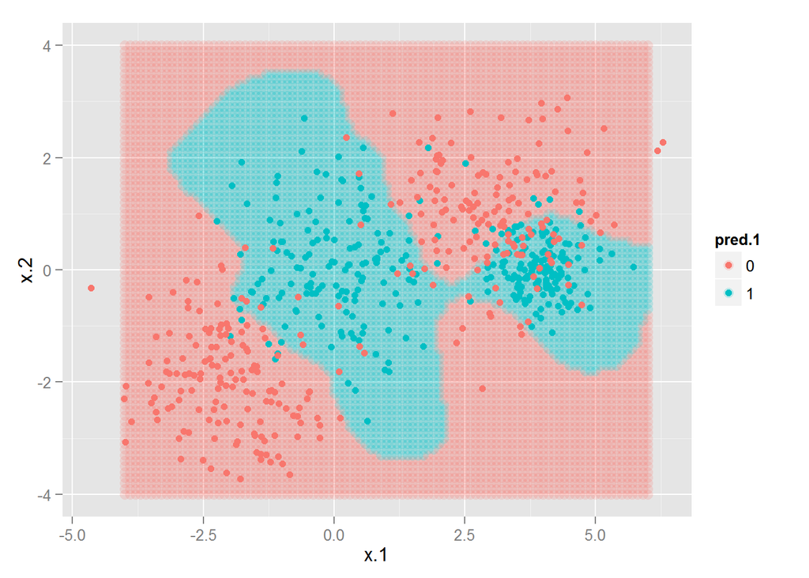

```r
dat.grid$pred.1 <- predict(svmFit.2, newdata = dat.grid[,1:2])

 ggplot(dat.grid, aes(x=x.1, y=x.2))+geom_point(size=3, alpha=0.2, aes(colour=pred.1)) +
    geom_point(data=dat.entrena, aes(colour=factor(clase)))
```

Obtenemos una media de 0.15175

## 4. Conclusiones

- La era de *Big data* incrementa el uso de los **Algoritmos de Aprendizaje Máquina**.
- Existen **criterios formales** que un algoritmo debe cumplir **para poder aprender**.
- No todo algoritmo cumple con esos criterios.
- No todo algoritmo debe aprender, **existen muchos otros fines de los algoritmos**.
- En la práctica **los algoritmos que vimos en clase han demostrado aprender** y por eso se usan como *Algoritmos de Aprendizaje*, si embargo hay que tomarlo con cautela y siempre **verificar que los supuestos se cumplan** (aunque sea de manera relajada como por ejemplo el Teorema Central del Li?mite).

## 5. Bibliografi?a

1. Shai, Shai. Understanding machine learning: from theory to algorithms. New York: Cambridge University Press, 2014.  
2. Notas del curso de Aprendizaje Estadí?stico del ITAM impartido por el Dr. Luis Felipe González Pérez, Agosto-diciembre 2014.